# Principal Component Analysis by Singular Value Decomposition

Author

Michael Knauss

## Motivation

Principal component analysis (PCA) is a dimension reduction technique commonly used in statistics to approximate datasets with a large number of variables. PCA can be used to reform a data matrix to retain the majority of the variation in the original data while also greatly reducing the dimensionality of the data. This means PCA is attempting to approximate the original data, but with a smaller matrix. Reducing the number of variables makes a dataset much easier to work with in many statistical modeling applications.

## Principal Components

PCA retains information from the original dataset by fitting lines that pass through the original data as much as possible. These lines are called principal components; they are new axes which are meant to spread the data out around a new origin. In linear algebra terms, this would be represented as a change of basis from your original variable axes into the new principal component axes.

Fitting a line to capture variability requires finding the vector that points in the direction of greatest covariance between variables. This is accomplished mathematically by finding the eigenvectors of the covariance matrix of the data. These eigenvectors tell us what direction to put our new axes in to retain the most variation and their corresponding eigenvalues will tell us how much variability these new axes are retaining.

#### PCA by Eigenvalue Decomposition

```r
data <- iris %>%
  select(-Species) %>%
  scale()

#Step 1
covariance <- cov(data)
#Step 2
eigen(covariance)
```

```
eigen() decomposition
$values
[1] 2.91849782 0.91403047 0.14675688 0.02071484

$vectors
           [,1]        [,2]       [,3]       [,4]
[1,]  0.5210659 -0.37741762  0.7195664  0.2612863
[2,] -0.2693474 -0.92329566 -0.2443818 -0.1235096
[3,]  0.5804131 -0.02449161 -0.1421264 -0.8014492
[4,]  0.5648565 -0.06694199 -0.6342727  0.5235971
```

## Singular Value Decomposition

The more computationally efficient way to perform PCA would be using singular value decomposition (SVD). Eigenvalue decomposition requires a square matrix to work so you first need to compute the covariance matrix and then find the eigenvalues through eigenvalue decomposition. SVD has the benefit of being able to perform the same task without first finding the covariance matrix. This can be extremely helpful in improving computing time when working with high dimensional data. SVD decomposes any rectangular matrix into 3 matrices. These three matrices contain all of the covariance information about the data needed to perform PCA, namely the eigenvectors of the covariance.

$$\bf X = USV^T$$

#### PCA by SVD

```r
#Single Step
svd <- svd(data)

#Reconstructing data
s <- diag(svd$d)
v <- as.matrix(svd$v)
u <- as.matrix(svd$u)
dat <- u %*% s %*% t(v)

# Shows formula above (all true)
# round(dat,10) == round(data,10)
```

- S is a diagonal matrix that holds what are called the singular values which serve the same purpose as the eigenvalues (and are for the most part proportional to their square root). Entries of S are arranged in descending order on the diagonals so that the most important dimensions in separating the data (retaining variance) are represented in the first columns of V.
- V gives eigenvectors or “loadings” which show variable importance in each principal component (PC). These weights show how much each variable is contributing in each PC and can be used to interpret what observations each PC is capturing/spreading apart.
- U is the final matrix that projects this information back into the dimensions of the original data.

To find the predictor values in each of the principal components, first perform SVD decomposition, then multiply the data with the V matrix to project into the principal component dimensions. The resulting matrix will be the same dimensions as the original data, but they will have been rescaled to represent values on the new axes.

#### Variance Captured

Each of the new axes are perpendicular to the others and are fit to capture as much variance in the data as possible. By using the singular values you are able to compute how much variance from the original data each principal component is capturing.

```r
#Square singular values and divide by sum to find proportion
varcap <- as.vector(diag(s %*% s / (sum(s %*% s))))
varcap
```

```
[1] 0.729624454 0.228507618 0.036689219 0.005178709
```

## Dimension Reduction

To perform dimension reduction you can take the first k singular values and you will have your data reproduced in a lower rank then before (reducing the dimensionality). This works because of the descending format of the singular values in S. This will cause the data to be projected back into a lower dimension than it was originally but still contain the majority of the information present in the data. This is commonly used in statistical applications for building predictive models and is also used in linear algebra for other tasks like matrix completion.

### Dimension Reduction Code

(Returns data in given number of principal component dimensions)

```r
pcabysvd <- function(dat, k, grouping){
  #Factoring grouping variable
  group <- dat %>%
    select({{grouping}}) %>%
    mutate(Group = factor({{grouping}})) %>%
    select(Group)

  #Scaling predictor variables
  dat <- dat %>% select(-{{grouping}})
  dat <- scale(dat)

  #Performing SVD
  svd <- svd(dat)
  s <- diag(svd$d)
  v <- as.matrix(svd$v)
  u <- as.matrix(svd$u)

  #Performing dimension reduction
  predpcdata <- dat %*% v
  pcvalues <- as.data.frame(predpcdata[,1:k])
  reduced <- cbind(pcvalues, group)
  return(reduced)
}
```

### Plotting on first two PC dimensions (mtcars data)

In this example, you can see how the first principal component does an extremely good job of separating cars by the number of cylinders they have. It is clear that four cylinder cars have a PC1 value of less than zero, six cylinder cars have a value around zero, and eight cylinder cars have a value of above zero. We have in turn transformed all 10 original predictors into a single variable that can help us more easily classify number of cylinders in a car.

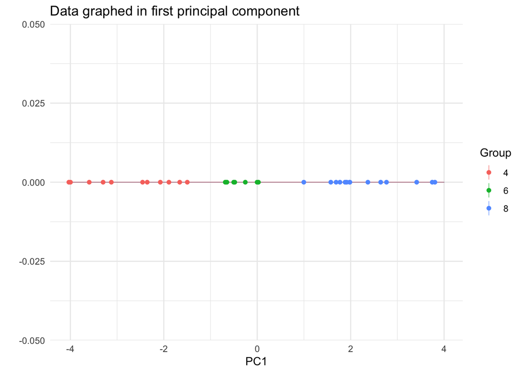

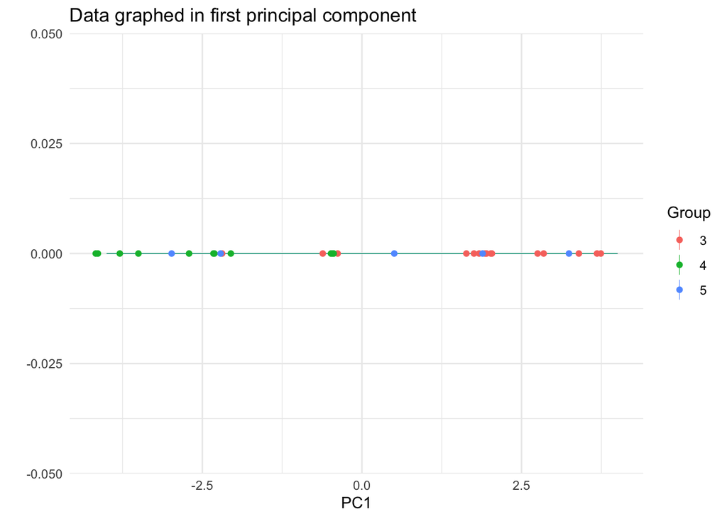

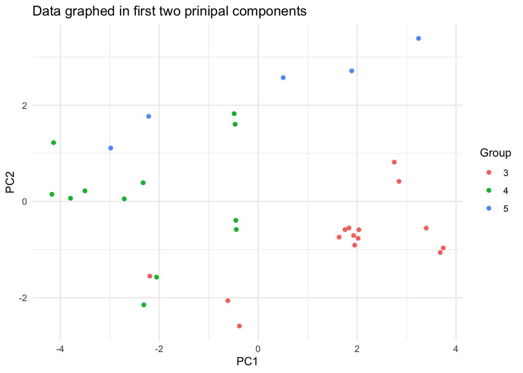